## Explanatory Data Analysis

### Inspecting Summary Statistics and Missing Data:

The variables in our the data set seem to have the most amount of missing data in Engine.HP, Engine.Cylinders and Number.of.Doors.

```r
library(tidyverse)
library(naniar)
library(caret)
library(ggcorrplot)
library(FNN)
library(car)
library(ggplot2)
library(rgl)
library(olsrr)
library(GGally)
library(leaps)
library(tree)
library(rpart)
library(gridExtra)
dataset <- read.csv("C:/Users/Joey/Desktop/applied-stats/datasets/data1.csv")

#glimpse(dataset) # looking at the var types of each

summary(dataset) # visually looking at the sum. stats of the vars in the data.
```

```
##      Make              Model                Year      Engine.Fuel.Type
##  Length:11914       Length:11914       Min.   :1990   Length:11914
##  Class :character   Class :character   1st Qu.:2007   Class :character
##  Mode  :character   Mode  :character   Median :2015   Mode  :character
##                                        Mean   :2010
##                                        3rd Qu.:2016
##                                        Max.   :2017
##
##    Engine.HP      Engine.Cylinders Transmission.Type  Driven_Wheels
##  Min.   :  55.0   Min.   : 0.000   Length:11914       Length:11914
##  1st Qu.: 170.0   1st Qu.: 4.000   Class :character   Class :character
##  Median : 227.0   Median : 6.000   Mode  :character   Mode  :character
##  Mean   : 249.4   Mean   : 5.629
##  3rd Qu.: 300.0   3rd Qu.: 6.000
##  Max.   :1001.0   Max.   :16.000
##  NA's   :69       NA's   :30
##  Number.of.Doors Market.Category    Vehicle.Size       Vehicle.Style
##  Min.   :2.000   Length:11914       Length:11914       Length:11914
##  1st Qu.:2.000   Class :character   Class :character   Class :character
##  Median :4.000   Mode  :character   Mode  :character   Mode  :character
##  Mean   :3.436
##  3rd Qu.:4.000
##  Max.   :4.000
##  NA's   :6
##   highway.MPG        city.mpg        Popularity        MSRP
##  Min.   : 12.00   Min.   :  7.00   Min.   :   2   Min.   :   2000
##  1st Qu.: 22.00   1st Qu.: 16.00   1st Qu.: 549   1st Qu.:  21000
##  Median : 26.00   Median : 18.00   Median :1385   Median :  29995
##  Mean   : 26.64   Mean   : 19.73   Mean   :1555   Mean   :  40595
##  3rd Qu.: 30.00   3rd Qu.: 22.00   3rd Qu.:2009   3rd Qu.:  42231
##  Max.   :354.00   Max.   :137.00   Max.   :5657   Max.   :2065902
##
```

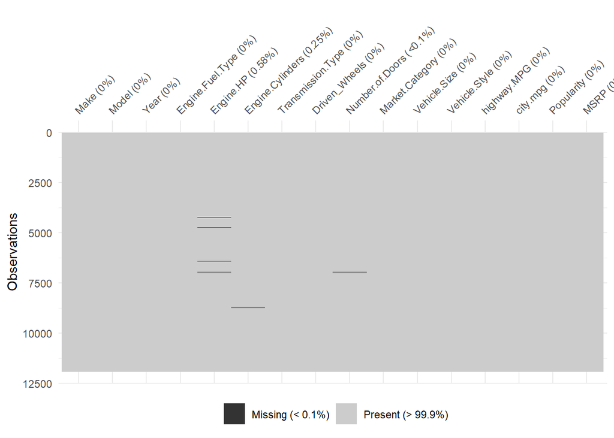

```r
vis_miss(dataset) # viz looking @ missing values
```

### NA Value: Deep Dive & Remedy

- Engine.HP = 69
- Engine.Cylinders = 30
- Number.of.Doors = 6

Many of the missing values seem to be found using automobile specification related websites(such as Edmunds, KBB, etc). To ensure we are not just deleting data at random will research the vehicles and input updated values into the data set where applicable so that we can fully utilize the features and data provided.

### Number of Doors:

The NA values here belong to the Tesla Model S and Ferrari FF. We were able to find and input these values successfully.

```r
#updating NA for Doors
dataset[6931:6935,9] <- 4 # Tesla model S
dataset[4667,9] <- 2 # Ferrari FF
```

### Engine Cylinders

Upon investigating the Engine Cylinders we found a couple of reasons for NA values to be present here.

Reason 1: - The Mazda RX-7, and RX-8 use a unique rotary Engine and thus technically have no cylinders.

Reason 2: - Electric Vehicles do not have engine cylinders, so it makes sense that we would find NA values in this group. For consistency in our data set we will update these vehicle types to 0. future consideration for a substitute value would be ideal here as the automobile market gains more and more Electric vehicles. This substitute value would help to leverage a way to add accurate predictions and values using this metric when comparing many EV.

Important Considerations: - Engine Cylinders would likely correlate with Engine.HP, and typically cars with Higher engine horsepower (more cylinders) are more expensive (MSRP). Electric vehicles such as Tesla models are listed as 0 cylinders and this could prove to be problematic in a prediction model because the value of Tesla would be high, but the HP/cylinders would be lower to the gas vehicle counter parts.

```r
dataset[1984:1985, 6] <- 0 # chevy bolt EV
dataset[3717:3720, 6] <- 0 # volkswagen e-golf
dataset[5779:5781,6] <- 0 # mitsubishi i-miev
dataset[8374,6] <- 0 # toyota rav4-ev
dataset[8696:8715, 6] <- 0 # mazda rotary engine RX7 AND RX8
```

### Engine HP

Certain cars specifically electric vehicles do not report “horsepower” but instead will report Kilowatts (KW). We expect to see many Missing values when dealing with Electric vehicles and to remedy this we have researched KW to HP conversions for specific models in attempt to keep the data intact, accurate and usable.

```r
dataset[8374,5] <- 154 # toyota RAV4-EV
dataset[2906:2909,5] <- 305 # lincoln Continental
dataset[4204:4207,5]<- 168 # ford escape
dataset[4915:4920,5]<- 193 # ford freestar
dataset[c(5826,5831,5832,5834,5840,5841),5]<- 305 # chevy impala flex-fuel
dataset[c(6909,6911,6917,6919),5]<-240 # lincoln mkz
dataset[6579, 5] <- 200 # mercedes-benz m-class
dataset[8375:8376,5]<-154 # 2013 rav4 EV and 2014
dataset[540:542, 5] <- 111 # fiat 500 e - from edmunds
dataset[9851:9855,5]<- 109 # kia soul Ev
dataset[4706:4707,5] <- 123 # honda fit Ev
dataset[c(4786,4790,4799),5] <- 143 # ford focus ev
dataset[5779,5] <- 66 # mitsubishi i-miev
dataset[6386:6395,5] <- 107 # nissan leaf
dataset[6923,5] <- 302 # base tsla model s 2014
dataset[6922,5] <- 302 # 2nd tsla model s 2014
dataset[6925,5] <- 362 # 3rd tsla model s 2014
dataset[6924,5] <- 416 # 4th tsla model s 2014
dataset[6926:6927,5]<- 329 # tsla model s 2015
dataset[6930, 5]<- 362 # tsla model s 2015
dataset[6928,5]<- 416 # tsla model s 2015
dataset[6929,5]<- 691 # tsla model s 2015
dataset[6932,5]<-259 # tsla model s 2016
dataset[6935,5]<-315
dataset[6934:6936,5] <- 373 # tsla model s 2016
dataset[6936,5]<-373# tsla model s 2016
dataset[c(6931,6937),5]<-417# tsla model s 2016
dataset[6939,5]<- 503# tsla model s 2016
dataset[c(6933,6938),5] <- 691# tsla model s 2016

dataset[11322:11324,4] <- 'regular unleaded' # suzuki verona missing fuel type


car_data <- dataset
```

### “Unknown” Data Values:

During the cleaning of our data we discovered “Unknown” values in the Transmission.Type category. These Unknown values are publicly and easily accessible information and we were able to update the database with the proper assignments after some research.

```r
car_data[1290:1291, 7] <- "AUTOMATIC" # oldsmobile achieva
car_data[4692,7]<- "MANUAL" # cheaper firebird
car_data[4693:4694,7]<- "AUTOMATIC" #more expensive firebird
car_data[6159,7] <- "MANUAL" # GMC Jimmy cheaper 99
car_data[6161,7] <- "AUTOMATIC" # GMC jimmy 99
car_data[6166,7] <- "MANUAL" #gmc jimmy 00
car_data[6175,7]<- "AUTOMATIC" # gmc jimmy 00
car_data[6367,7] <- "MANUAL" # chrysler le baron
car_data[6369,7] <- "AUTOMATIC"# chrysler le baron
car_data[c(8043,8044,8047,8048,8049,8050,8052,8054),7] <- "AUTOMATIC" # dodge ram 150
```

There are many chr and int types so we will change them into a factor where needed so that we can adequately plot the data.

```r
car_data$Make <- as.factor(car_data$Make)
car_data$Engine.Fuel.Type<- as.factor(car_data$Engine.Fuel.Type) # chr
car_data$Engine.HP<- as.numeric(car_data$Engine.HP) # dbl
car_data$Engine.Cylinders<-as.factor(car_data$Engine.Cylinders) # dbl
car_data$Transmission.Type<-as.factor(car_data$Transmission.Type) # chr
car_data$Driven_Wheels<- as.factor(car_data$Driven_Wheels) # chr
car_data$Number.of.Doors<- as.integer(car_data$Number.of.Doors) # dbl
car_data$Vehicle.Size<-as.factor(car_data$Vehicle.Size) # chr
car_data$Vehicle.Style<-as.factor(car_data$Vehicle.Style) # chr
car_data$Market.Category<-as.factor(car_data$Market.Category) # chr
```

### “Not Applicable” Values:

Upon investigation of the Market.Category section we found many “N/A” values (3,742). These values seem to be implicitly added N/A values, which could in fact mean there is no applicable group that it fits into per the source/creation of the data set. We will trust that the vehicles in question truly did not fit into any specific category and change this N/A to “No Category” to avoid any confusion with Missing value data.

```r
# change so that we can handle the "N/A" which is NOT an NA
car_data$Market.Category<-as.character(car_data$Market.Category)
#sum(car_data$Market.Category == "N/A") #3742 this is our benchmark

# reading as not applicable we will change to no category
car_data$Market.Category[car_data$Market.Category == "N/A"] <- "No Category"

# sanity check should be 0
#sum(car_data$Market.Category == "N/A")

# change to match rest of data type (factor)
car_data$Market.Category<-as.factor(car_data$Market.Category)
```

### Typo

During some preliminary visualization of the data we discovered an outlier in Audi MPG. We researched and confirmed that this data was incorrect and replaced it with the appropriate value.

```r
car_data[1120,13] <- 34
```

Finally we will remove the “model” variable since it presents no obvious value to our data and will not be used as a “predictor”.

A NA sanity check will be displayed to ensure we have addressed the values missing in our data set.

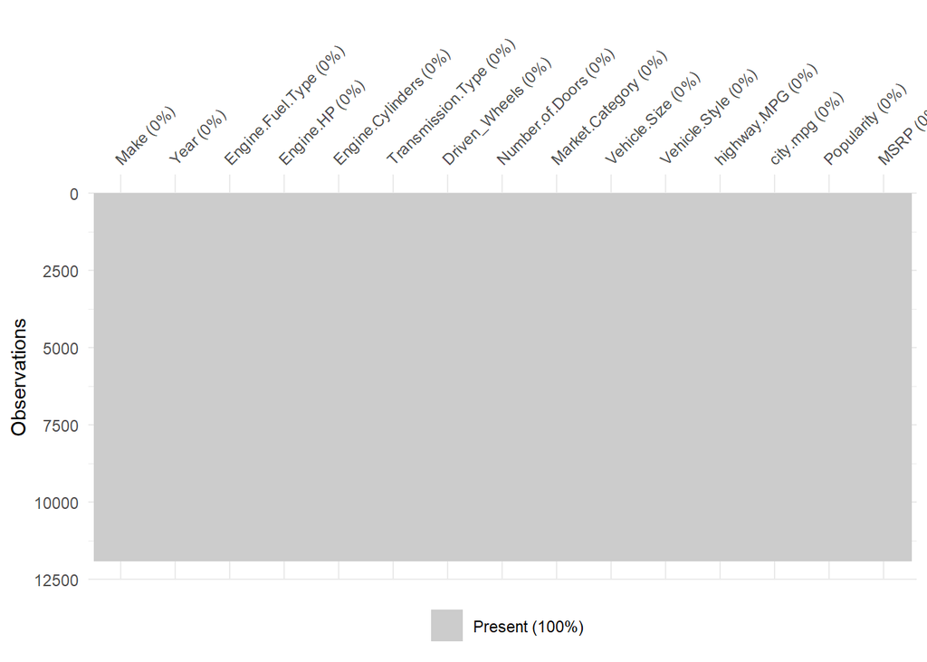

```r
#glimpse(car_data) # view the df
car_data <- car_data[,-2] # rm the model column
#glimpse(car_data) # sanity check the df

vis_miss(car_data)
```

### Visualization of The Data

### Year / MSRP

Figure 1.A: - Shows us a bi-modal distribution of the Log MSRP values. Upon further investigation and consultation, it was uncovered that certain values of the data tend to lose accuracy/reliability.

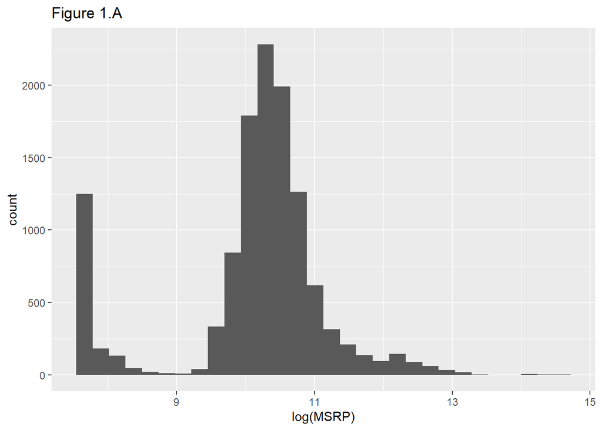

```r
car_data %>% ggplot(aes(log(MSRP)))+
  geom_histogram() + ggtitle('Figure 1.A')
```

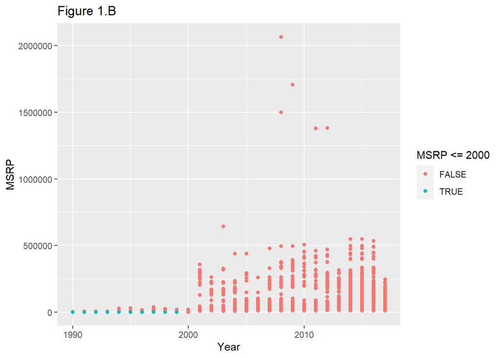

```r
car_data%>% ggplot(aes(Year, MSRP))+
  geom_point(aes(color = MSRP <=2000)) + ggtitle('Figure 1.B')
```

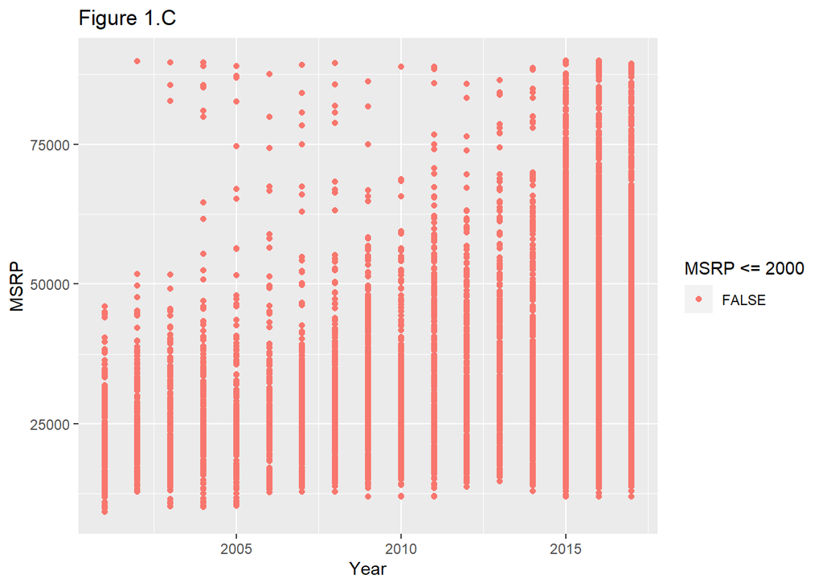

```r
# car_data %>% filter(MSRP < 60000)%>% ggplot(aes(log(MSRP)))+
#   geom_histogram(aes(fill = Year > 2000)) + ggtitle('Figure 1.C')

car_data%>% filter(MSRP < 90000 & Year >2000) %>% ggplot(aes(Year, MSRP))+
  geom_point(aes(color = MSRP <=2000)) + ggtitle('Figure 1.C')
```

### Adjustments to The Dataset

- Remove data associated with “exotic” types of vehicles which represent astronomical prices
- Filter out electric vehicles

### Feature Engineering

This data set contains multiple categorical variables that contain multiple levels. When utilizing a feature selection tool such as glmnet the result can leave us with a lot of noise. So that we can work with a less noisy data set we have created new variables to narrow our selection of features.

### Engineering - Vehicle Style

```r
car_df$Style_Van <- as.factor(ifelse(car_df$Vehicle.Style == "Cargo Minivan"|
                                car_df$Vehicle.Style == "Cargo Van"|
                                car_df$Vehicle.Style == "Passenger Van"|
                                car_df$Vehicle.Style =="Passenger Minivan", 1,0))

car_df$Style_SUV <- as.factor(ifelse(car_df$Vehicle.Style == "2dr SUV" |
                                car_df$Vehicle.Style == "Convertible SUV" |
                                car_df$Vehicle.Style == "4dr SUV", 1, 0))

car_df$Style_Coupe <- as.factor(ifelse(car_df$Vehicle.Style == "Coupe",1,0))

car_df$Style_Sedan <- as.factor(ifelse(car_df$Vehicle.Style == "Sedan",1,0))

car_df$Style_Hatchback <- as.factor(ifelse(car_df$Vehicle.Style == "2dr Hatchback" |
                                      car_df$Vehicle.Style == "4dr Hatchback",1,0))

car_df$Style_Truck <- as.factor(ifelse(car_df$Vehicle.Style == "Crew Cab Pickup"|
                                  car_df$Vehicle.Style == "Extended Cab Pickup"|
                                  car_df$Vehicle.Style == "Regular Cab Pickup", 1, 0))

car_df$Style_Convertible <- as.factor(ifelse(car_df$Vehicle.Style == "Convertible",1,0))

car_df$Style_Wagon <- as.factor(ifelse(car_df$Vehicle.Style == "Wagon",1,0))

car_df <- car_df[,-11]
#car_df <- as.data.frame(car_df)
```

### Engineering - Market Category

```r
car_df$Flex_fuel <- as.double(ifelse(car_df$Market.Category == "Flex Fuel,Diesel"|
                                 car_df$Market.Category == "Flex Fuel,Hybrid"|
                                  car_df$Market.Category == "Flex Fuel,Luxury,High-Performance"|
                                  car_df$Market.Category == "Flex Fuel,Performance"|
                                  car_df$Market.Category == "Flex Fuel,Performance,Hybrid"|
                                  car_df$Market.Category == "Flex Fuel"|
                                  car_df$Market.Category == "Flex Fuel,Factory Tuner,Luxury,High-Performance"|
                                  car_df$Market.Category == "Flex Fuel,Luxury"|
                                  car_df$Market.Category == "Flex Fuel,Luxury,Performance"|
                                  car_df$Market.Category == "Flex Fuel,Performance,Hybrid",1,0))

car_df$Crossover <- as.double(ifelse(car_df$Market.Category == "Crossover"|
                                         car_df$Market.Category == "Crossover,Exotic,Luxury,High-Performance"|
                                         car_df$Market.Category == "Crossover,Factory Tuner,Luxury,High-Performance"|
                                         car_df$Market.Category == "Crossover,Flex Fuel,Performance"|
                                         car_df$Market.Category == "Crossover,Hatchback,Factory Tuner,Performance"|
                                         car_df$Market.Category == "Crossover,Hatchback,Performance"|
                                         car_df$Market.Category == "Crossover,Luxury"|
                                         car_df$Market.Category == "Crossover,Diesel"|
                                         car_df$Market.Category == "Crossover,Exotic,Luxury,Performance"|
                                         car_df$Market.Category == "Crossover,Factory Tuner,Luxury,Performance"|
                                         car_df$Market.Category == "Crossover,Flex Fuel"|
                                         car_df$Market.Category == "Crossover,Flex Fuel,Luxury,Performance"|
                                         car_df$Market.Category == "Crossover,Hatchback"|
                                         car_df$Market.Category == "Crossover,Hatchback,Luxury"|
                                         car_df$Market.Category == "Crossover,Hybrid"|
                                         car_df$Market.Category == "Crossover,Luxury,Diesel"|
                                         car_df$Market.Category == "Crossover,Luxury,Hybrid"|
                                         car_df$Market.Category == "Crossover,Luxury,Performance,Hybrid",1,0))


car_df$Diesel <- as.double(ifelse(car_df$Market.Category == "Diesel"|
                                      car_df$Market.Category == "Diesel,Luxury",1,0))

car_df$Exotic <- as.double(ifelse(car_df$Market.Category == "Exotic"|
                                     car_df$Market.Category == "Exotic,Factory Tuner,Luxury,High-Performance"|
                                      car_df$Market.Category == "Exotic,Flex Fuel,Factory Tuner,Luxury,High-Performance"|
                                      car_df$Market.Category == "Exotic,High-Performance"|
                                      car_df$Market.Category == "Exotic,Luxury,High-Performance"|
                                      car_df$Market.Category == "Exotic,Luxury,Performance"|
                                      car_df$Market.Category == "Exotic,Factory Tuner,High-Performance"|
                                      car_df$Market.Category == "Exotic,Factory Tuner,Luxury,Performance"|
                                      car_df$Market.Category == "Exotic,Flex Fuel,Luxury,High-Performance"|
                                      car_df$Market.Category == "Exotic,Luxury"|
                                      car_df$Market.Category == "Exotic,Luxury,High-Performance,Hybrid"|
                                      car_df$Market.Category == "Exotic,Performance",1,0))


car_df$Factory <- as.double(ifelse(car_df$Market.Category == "Factory"|
                                      car_df$Market.Category == "Factory Tuner,High-Performance"|
                                       car_df$Market.Category == "Factory Tuner,Luxury,High-Performance"|
                                       car_df$Market.Category == "Factory Tuner,Performance"|
                                       car_df$Market.Category == "Factory Tuner,Luxury"|
                                       car_df$Market.Category == "Factory Tuner,Luxury,Performance",1,0))

car_df$Hatchback <- as.double(ifelse(car_df$Market.Category == "Hatchback"|
                                         car_df$Market.Category == "Hatchback,Factory Tuner,High-Performance"|
                                         car_df$Market.Category =="Hatchback,Factory Tuner,Performance"|
                                         car_df$Market.Category == "Hatchback,Hybrid"|
                                         car_df$Market.Category == "Hatchback,Luxury,Hybrid"|
                                         car_df$Market.Category == "Hatchback,Performance"|
                                         car_df$Market.Category == "Hatchback,Diesel"|
                                         car_df$Market.Category == "Hatchback,Factory Tuner,Luxury,Performance"|
                                         car_df$Market.Category == "Hatchback,Flex Fuel"|
                                         car_df$Market.Category == "Hatchback,Luxury"|
                                         car_df$Market.Category == "Hatchback,Luxury,Performance",1,0))

car_df$Hybrid <- as.double(ifelse(car_df$Market.Category == "Hybrid",1,0))

car_df$Luxury <- as.double(ifelse(car_df$Market.Category == "Luxury"|
                                      car_df$Market.Category == "Luxury,High-Performance"|
                                      car_df$Market.Category == "Luxury,Hybrid"|
                                      car_df$Market.Category == "Luxury,Performance,Hybrid"|
                                      car_df$Market.Category == "Luxury,High-Performance,Hybrid"|
                                      car_df$Market.Category == "Luxury,Performance",1,0))

car_df$High_Performance <- as.double(ifelse(car_df$Market.Category == "High-Performance",1,0))

car_df$Performance <- as.double(ifelse(car_df$Market.Category == "Performance"|
                                           car_df$Market.Category == "Performance,Hybrid",1,0))

car_df$No_Category <- as.double(ifelse(car_df$Market.Category == "No Category",1,0))


car_df <- car_df[,-9]
```

### Engineering - Fuel Type

```r
car_df$flex_Fuel_intake <- as.double(ifelse(car_df$Engine.Fuel.Type == "flex-fuel (premium unleaded recommended/E85"|
                                                car_df$Engine.Fuel.Type == "flex-fuel (unleaded/natural gas)"|
                                                car_df$Engine.Fuel.Type == "flex-fuel (unleaded/E85)"|
                                                car_df$Engine.Fuel.Type == "flex-fuel (premium unleaded required/E85",1,0))

car_df$diesel_Fuel_intake <- as.double(ifelse(car_df$Engine.Fuel.Type == "diesel",1,0))

car_df$nat_fuel_intake <- as.double(ifelse(car_df$Engine.Fuel.Type == "natrual gas",1,0))

car_df$reg_fuel_intake <- as.double(ifelse(car_df$Engine.Fuel.Type =="regular unleaded",1,0))

car_df$electric_intake <- as.double(ifelse(car_df$Engine.Fuel.Type == "electric",1,0))

car_df$prem_fuel_intake <- as.double(ifelse(car_df$Engine.Fuel.Type == "premium unleaded (required)"|
                                                car_df$Engine.Fuel.Type == "premium unleaded (recommended)",1,0))

car_df <- car_df[,-3]
```

### Engineering - Make

```r
car_df$German_Build <- as.double(ifelse(car_df$Make == "BMW"|
                                            car_df$Make == "Mercedes-Benz"|
                                            car_df$Make == "Volkswagen"|
                                            car_df$Make == "Audi"|
                                            car_df$Make == "Maybach"|
                                            car_df$Make == "Porsche",1,0))

car_df$french_build <- as.double(ifelse(car_df$Make == "Bugatti",1,0))

car_df$Italy_Build <- as.double(ifelse(car_df$Make == "Alfa Romeo"|
                                           car_df$Make == "Ferrari"|
                                           car_df$Make == "FIAT"|
                                           car_df$Make == "Lamborghini"|
                                           car_df$Make == "Maserati",1,0))

car_df$Japan_build <- as.double(ifelse(car_df$Make == "Acura"|
                                           car_df$Make == "Honda"|
                                           car_df$Make == "Infiniti"|
                                           car_df$Make == "Lexus"|
                                           car_df$Make == "Mazda"|
                                           car_df$Make == "Suzuki"|
                                           car_df$Make == "Subaru"|
                                           car_df$Make == "Nissan"|
                                           car_df$Make == "Scion"|
                                           car_df$Make == "Mitsubishi"|
                                           car_df$Make == "Toyota",1,0))

car_df$finland_build <- as.double(ifelse(car_df$Make == "Saab",1,0))

car_df$Netherlands_build <- as.double(ifelse(car_df$Make == "Spyker",1,0))

car_df$SKorea_build <- as.double(ifelse(car_df$Make == "Genesis"|
                                            car_df$Make == "Hyundai"|
                                            car_df$Make == "Kia",1,0))

car_df$sweden_build <- as.double(ifelse(car_df$Make == "Volvo",1,0))


car_df$UK_build <- as.double(ifelse(car_df$Make == "Aston Martin"|
                                        car_df$Make == "Bentley"|
                                        car_df$Make == "Land Rover"|
                                        car_df$Make == "Lotus"|
                                        car_df$Make == "McLaren"|
                                        car_df$Make == "Rolls-Royce",1,0))

car_df$US_build <- as.double(ifelse(car_df$Make == "Buick"|
                                        car_df$Make == "Cadillac"|
                                        car_df$Make == "Chevrolet"|
                                        car_df$Make == "GMC"|
                                        car_df$Make == "Chrysler"|
                                        car_df$Make == "Dodge"|
                                        car_df$Make == "Ford"|
                                        car_df$Make == "Hummer"|
                                        car_df$Make == "Tesla"|
                                        car_df$Make == "Plymouth"|
                                        car_df$Make == "Pontiac"|
                                        car_df$Make == "Oldsmobile"|
                                        car_df$Make == "Lincoln",1,0))

car_df <- car_df[,-1]
```

### Correlation Heat Map

- To visualize the link between variables, we created a correlation heat map graphic .It is used in regression analysis to ascertain whether there is a significant correlation between the independent (predictor) and dependent (response) variables. If there is a significant correlation, it may be possible to forecast the dependent variable using the independent variable. The selection of the regression model and its underlying assumptions can then be guided by this information.

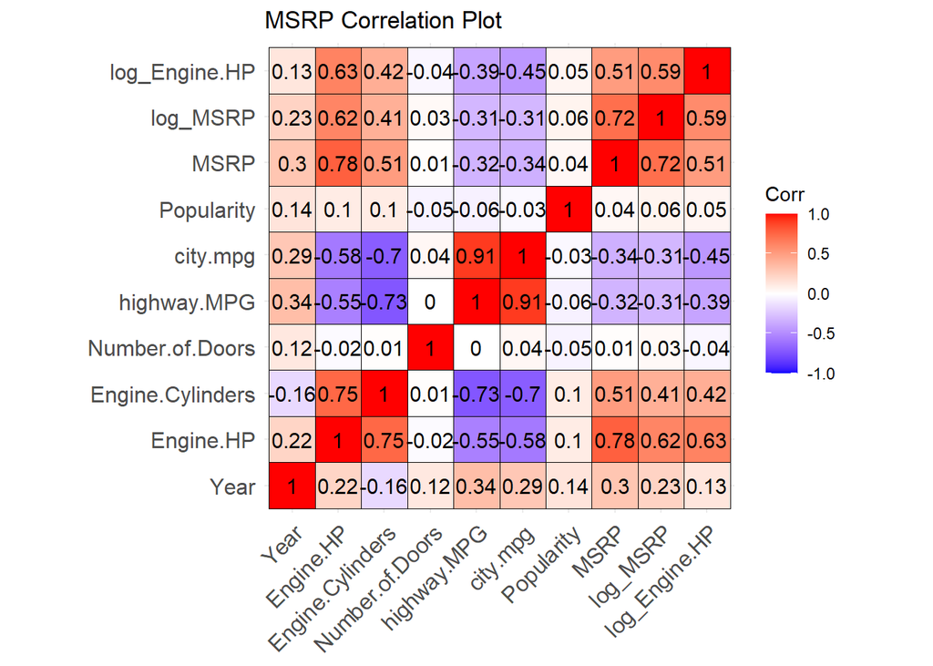

```r
# removing no-numerical categories so that we can viz correlative relationships
car_data_correlations <- car_df[,-c(4,5,7,14:48)]

car_data_correlations<- lapply(car_data_correlations,as.integer)

car_data_correlations<- as.data.frame(car_data_correlations)
# calling cor function to put into var.
corr_data <- cor(car_data_correlations)

# generate the plot
ggcorrplot(corr_data, outline.color = "black", lab = TRUE, title = 'MSRP Correlation Plot')
```

### Test/Validation Split

Before proceeding with model creation it is imperative that we split the data into a test and validation set. The test-Validation splitting of the data enables evaluation of the model’s performance on unknown (new) data. This aids in avoiding an over fitting model, which happens when a model is too closely fitted to the training set of data and fails to perform well on the test (validation) set.

```r
# car_df which includes feat engineering
set.seed(7)

trainIndex<-createDataPartition(car_df$log_MSRP,p=.8,list=F)  #p: proportion of data in train

training <- car_df[trainIndex,]
validate <- car_df[-trainIndex,]


# backup_df no feat engineering
set.seed(7)

trainIndex_b<-createDataPartition(backup_df$log_MSRP,p=.8,list=F)  #p: proportion of data in train

training_b <- backup_df[trainIndex,]
validate_b <- backup_df[-trainIndex,]


# test/train/validation split for validation sections
set.seed(7)
train_df <- .8
valid_df <- .1
test_df <- .1

sampleSizeTrain <- floor(train_df * nrow(backup_df))
sampleSizeValid <- floor(valid_df * nrow(backup_df))
sampleSizeTest <- floor(test_df * nrow(backup_df))

index_train<- sort(sample(seq_len(nrow(backup_df)), size = sampleSizeTrain))
index_not_train<-setdiff(seq_len(nrow(backup_df)),index_train)
index_valid <- sort(sample(seq_len(nrow(backup_df)),size = sampleSizeValid))
index_test <- sort(sample(seq_len(nrow(backup_df)),size=sampleSizeTest))

car_train <- backup_df[index_train,]
car_valid <- backup_df[index_valid,]
car_test <- backup_df[index_test,]
```

### Regression Model Creation

### Simple (Low Complexity) Regression Model

For the creation/building of this model we looked at correlative relationships in our heat map to determine whether there appeared to be a significant correlation between X variables (predictors) and MSRP (response) variables. A significant correlation, means it may be possible to forecast the dependent variable using the independent variable in a regression setting.

No Feature Selection Algorithms were used to create this model as the objective was to create model with high simplicity, and intuitive relationships.

Because the model was based on a correlation heat map we included VIF in our statistical outputs to ensure that we do have not created a model with high multicollinearity.

#### *Practical Significance | Year Predictor:*

- A one year increase (a 1 year more current vehicle) car will result in a estimated 1.3% increase in the median MSRP with a 95% confidence interval of 1.2%-1.4%. The practical significance of this would be determined by each individual buyer in the market for a car since they will have relatively different purchasing power. Additionally market conditions that would make economic conditions more or less friendly to for buyers would ultimately affect the digestion or acceptance of this increase in picking models of various years.
- Because cars typically keep a specific model trim for a few years, applying this knowledge to someone shopping for a specific model type can come in handy as they would be able to potentially save money looking for “older” versions of identical models.
- Alternatively someone with more expendable income and buying power may find that the 1.3% increase is worth buying a “newer” model as a small price to pay for potentially less miles, upgraded technologies, or overall wear on the vehicle.

#### *Practical Significance | Log Engine Horse Power Predictor:*

- A doubling of increase of Engine Horsepower is associated with an 80% increase in the Median MSRP. Practically speaking when you have a buyer who is looking to maximize vehicle performance (power, speed, acceleration) they are typically looking for a specific type of higher performance vehicle which are generally known to cost more compared to vehicles with a more functional purpose. Similar to the Year Predictor the significance of the Horse Power predictor would depend on the buyer among other factors.
- Understanding the price to performance (horsepower) trade off when purchasing a vehicle can be of practical significance to buyers looking to predict what a car of a certain performance would cost, as well those looking to find alternative models in which horsepower is not as great.

#### *Statistical Significance | Year Predictor:*

- At an alpha = .05 level of significance there is an overwhelming amount of evidence to suggest that the Year coefficient is different than zero (p-value < .0001).

#### *Statistical Significance | Log Engine Horse Power Predictor:*

```r
# removing MSRP
training_slr <- training[,-11]
validate_slr <- validate[,-11]

# linear regression model
car_model_fit <- lm(log_MSRP~Year+log(Engine.HP),training_slr)

# k-fold cross validation (10 fold)
set.seed(7)
train_control<- trainControl(method = "cv", number = 10, repeats = 1)
simple_kfold <- train(log_MSRP~Year+log(Engine.HP),
                  data=training_slr,
                  method = "lm", trControl = train_control,
                  metric = "RMSE")

# view k-fold performance
# print(simple_kfold)

# variance inflation factor
vif(car_model_fit)
```

```
##           Year log(Engine.HP)
##       1.051339       1.051339
```

```r
# coefficients
summary(car_model_fit)
```

```
##
## Call:
## lm(formula = log_MSRP ~ Year + log(Engine.HP), data = training_slr)
##
## Residuals:
##      Min       1Q   Median       3Q      Max
## -0.60171 -0.14115 -0.01381  0.12929  0.74667
##
## Coefficients:
##                  Estimate Std. Error t value Pr(>|t|)
## (Intercept)    -2.029e+01  1.067e+00  -19.01   <2e-16 ***
## Year            1.294e-02  5.343e-04   24.22   <2e-16 ***
## log(Engine.HP)  8.458e-01  7.139e-03  118.48   <2e-16 ***
## ---
## Signif. codes:  0 '***' 0.001 '**' 0.01 '*' 0.05 '.' 0.1 ' ' 1
##
## Residual standard error: 0.2011 on 7322 degrees of freedom
## Multiple R-squared:  0.6953, Adjusted R-squared:  0.6952
## F-statistic:  8354 on 2 and 7322 DF,  p-value: < 2.2e-16
```

```r
# confidence intervals for coef.
confint.lm(car_model_fit)
```

```
##                       2.5 %       97.5 %
## (Intercept)    -22.38312496 -18.19795658
## Year             0.01189508   0.01398973
## log(Engine.HP)   0.83176185   0.85974929
```

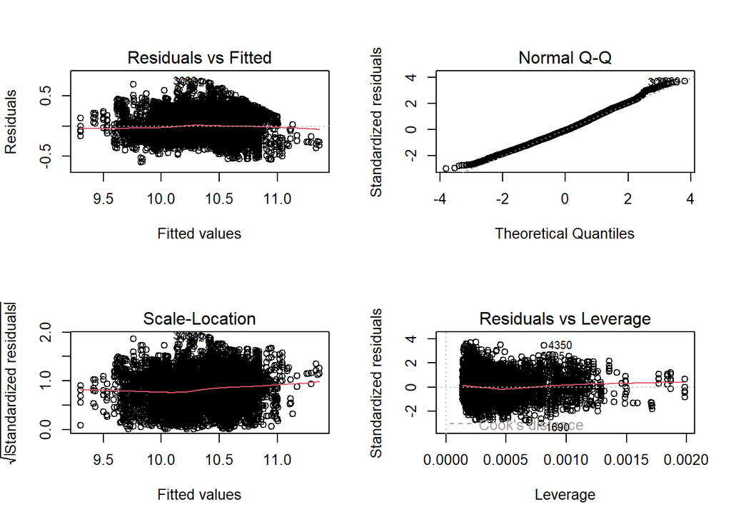

```r
# diagnostics
par(mfrow= c(2,2))
plot(car_model_fit)
```

```r
# diagnostic check with resid. histogram.
#ols_plot_diagnostics(car_model_fit)

# prediction on validation data
car_model_prediction <- predict(car_model_fit, interval = "predict", newdata = validate_slr)

pred_RMSE <- sqrt(mean((car_model_prediction[,1] - validate_slr$log_MSRP)^2))


# # functions for returning RMSE and ASE
# RMSE_func<- function(error){sqrt(mean(error^2))}
ASE_func <- function(error){mean(error^2)}
#
# RMSE_func(car_model_fit$residuals)
ase <- ASE_func(car_model_fit$residuals)

rsqr <- summary(car_model_fit)$r.squared
adj_rsqr<- summary(car_model_fit)$adj.r.squared

cat("RMSE: ", pred_RMSE, "\nASE: ", ase, "\nR-Squared", rsqr, "\nAdj.R-Squared", adj_rsqr)
```

```
## RMSE:  0.2036062
## ASE:  0.04043314
## R-Squared 0.6952946
## Adj.R-Squared 0.6952114
```

#### LASSO Penalized Regression

The following code chunk will run 5 fold cross validation as well as LASSO feature selection.

```r
set.seed(7)

training_glm <- training[,-11]
validate_glm <-validate[,-11]

lambda <- seq(0,.3, by = .01)
fitControl2 <- trainControl(method = "repeatedcv", number = 5, repeats = 1)
glmnet.fit2 <- train(log_MSRP~.,
                    data = training_glm,
                    method = "glmnet",
                    trControl = fitControl2,
                    tuneGrid = expand.grid(alpha = 1, lambda = lambda))


glmnet.fit2
```

```
## glmnet
##
## 7325 samples
##   46 predictor
##
## No pre-processing
## Resampling: Cross-Validated (5 fold, repeated 1 times)
## Summary of sample sizes: 5861, 5859, 5860, 5859, 5861
## Resampling results across tuning parameters:
##
##   lambda  RMSE       Rsquared   MAE
##   0.00    0.1368708  0.8588238  0.1085257
##   0.01    0.1476599  0.8385759  0.1169166
##   0.02    0.1592684  0.8172874  0.1263983
##   0.03    0.1710985  0.7944525  0.1359328
##   0.04    0.1829627  0.7695012  0.1458705
##   0.05    0.1936986  0.7459500  0.1549594
##   0.06    0.2028256  0.7264517  0.1628382
##   0.07    0.2110902  0.7090140  0.1698417
##   0.08    0.2181309  0.6960014  0.1759253
##   0.09    0.2249935  0.6834097  0.1818941
##   0.10    0.2313040  0.6731739  0.1873492
##   0.11    0.2361948  0.6711006  0.1914232
##   0.12    0.2410124  0.6711006  0.1953221
##   0.13    0.2461420  0.6711006  0.1994023
##   0.14    0.2515646  0.6711006  0.2037222
##   0.15    0.2572616  0.6711006  0.2082457
##   0.16    0.2632154  0.6711006  0.2129607
##   0.17    0.2694089  0.6711006  0.2178688
##   0.18    0.2758259  0.6711006  0.2229432
##   0.19    0.2824513  0.6711006  0.2281846
##   0.20    0.2892707  0.6711006  0.2336261
##   0.21    0.2962709  0.6711006  0.2392341
##   0.22    0.3034392  0.6711006  0.2449918
##   0.23    0.3107640  0.6711006  0.2508943
##   0.24    0.3182346  0.6711006  0.2569500
##   0.25    0.3258409  0.6711006  0.2631572
##   0.26    0.3335736  0.6711006  0.2695057
##   0.27    0.3414242  0.6711006  0.2760007
##   0.28    0.3493847  0.6711006  0.2826332
##   0.29    0.3574478  0.6711006  0.2894066
##   0.30    0.3640419  0.6449820  0.2949552
##
## Tuning parameter 'alpha' was held constant at a value of 1
## RMSE was used to select the optimal model using the smallest value.
## The final values used for the model were alpha = 1 and lambda = 0.
```

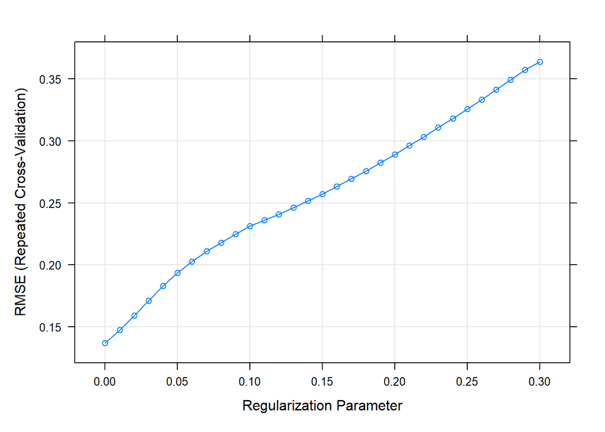

```r
plot(glmnet.fit2)
```

```r
#opt.pen2<- glmnet.fit2$finalModel$lambdaOpt
#coef(glmnet.fit2$finalModel,opt.pen2)
```

### GLMNET Selected Model

Using the results from our LASSO model we will use the suggested features to create a new regression model:

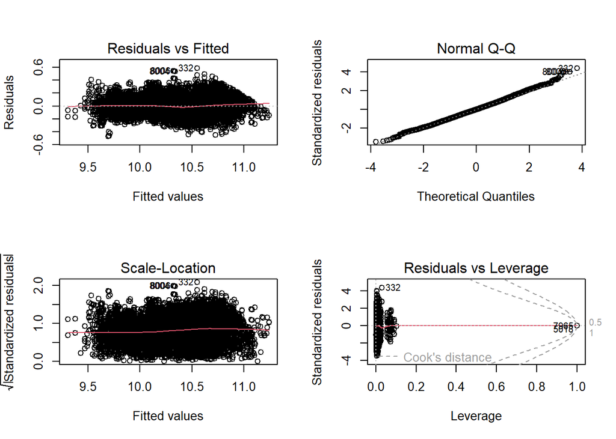

```r
set.seed(7)
# remove features not selected by LASSO
glm_df <- training_glm[,!names(training_glm) %in% c("Engine.Cylinders12","Engine.Cylinders16","Style_Sedan",
                                            "nat_fuel_intake","electric_intake","french_build",
                                            "Netherlands_build", "Engine.HP", "Style_Wagon")]

# create glm model
glm_model <- lm(log_MSRP~., glm_df)

# view diagnostics
par(mfrow=c(2,2))
plot(glm_model)
```

```r
glm_prediction <- predict(glm_model, interval = "predict", newdata = validate_glm)

pred_RMSE <- sqrt(mean((glm_prediction[,1] - validate_glm$log_MSRP)^2))

summary(glm_model)
```

```
##
## Call:
## lm(formula = log_MSRP ~ ., data = glm_df)
##
## Residuals:
##      Min       1Q   Median       3Q      Max
## -0.47092 -0.09084 -0.00393  0.08684  0.58487
##
## Coefficients:
##                                  Estimate Std. Error t value Pr(>|t|)
## (Intercept)                    -1.218e+01  1.112e+00 -10.951  < 2e-16 ***
## Year                            9.516e-03  5.765e-04  16.508  < 2e-16 ***
## Engine.Cylinders3              -4.669e-02  5.841e-02  -0.799  0.42413
## Engine.Cylinders4              -9.827e-02  4.337e-02  -2.266  0.02349 *
## Engine.Cylinders5              -1.440e-01  4.549e-02  -3.166  0.00155 **
## Engine.Cylinders6              -5.531e-02  4.332e-02  -1.277  0.20177
## Engine.Cylinders8              -4.398e-02  4.366e-02  -1.007  0.31386
## Engine.Cylinders10              1.139e-01  1.440e-01   0.791  0.42910
## Transmission.TypeAUTOMATIC      2.217e-02  9.149e-03   2.423  0.01541 *
## Transmission.TypeDIRECT_DRIVE  -1.315e-01  1.373e-01  -0.958  0.33797
## Transmission.TypeMANUAL        -7.012e-02  9.355e-03  -7.495 7.41e-14 ***
## Driven_Wheelsfour wheel drive   1.489e-02  8.462e-03   1.760  0.07845 .
## Driven_Wheelsfront wheel drive -7.233e-02  5.364e-03 -13.484  < 2e-16 ***
## Driven_Wheelsrear wheel drive  -4.658e-02  6.407e-03  -7.270 3.96e-13 ***
## Number.of.Doors                 2.147e-02  3.682e-03   5.830 5.77e-09 ***
## Vehicle.SizeLarge               8.359e-02  6.736e-03  12.410  < 2e-16 ***
## Vehicle.SizeMidsize             1.349e-02  4.924e-03   2.739  0.00618 **
## highway.MPG                    -6.942e-03  9.955e-04  -6.974 3.36e-12 ***
## city.mpg                        1.365e-02  8.944e-04  15.265  < 2e-16 ***
## Popularity                     -1.991e-06  1.231e-06  -1.618  0.10569
## log_Engine.HP                   6.699e-01  1.302e-02  51.451  < 2e-16 ***
## Style_Van1                      7.261e-02  9.141e-03   7.943 2.27e-15 ***
## Style_SUV1                      6.680e-02  8.224e-03   8.123 5.30e-16 ***
## Style_Coupe1                    4.427e-02  1.038e-02   4.265 2.02e-05 ***
## Style_Hatchback1               -3.377e-02  1.828e-02  -1.848  0.06470 .
## Style_Truck1                   -4.867e-02  8.873e-03  -5.485 4.27e-08 ***
## Style_Convertible1              2.142e-01  1.092e-02  19.610  < 2e-16 ***
## Flex_fuel                      -7.220e-02  1.575e-02  -4.584 4.63e-06 ***
## Crossover                       2.155e-02  1.245e-02   1.731  0.08354 .
## Diesel                         -2.918e-03  2.240e-02  -0.130  0.89636
```

[output cut: 11 more lines]

```
## prem_fuel_intake               -2.520e-01  3.279e-02  -7.684 1.74e-14 ***
## German_Build                    6.633e-03  3.746e-02   0.177  0.85947
## Italy_Build                    -6.438e-02  4.291e-02  -1.500  0.13355
## Japan_build                    -1.142e-01  3.732e-02  -3.059  0.00223 **
## finland_build                  -2.517e-02  4.124e-02  -0.610  0.54166
## SKorea_build                   -1.677e-01  3.798e-02  -4.416 1.02e-05 ***
## sweden_build                    2.843e-02  3.800e-02   0.748  0.45440
## UK_build                        5.289e-02  4.075e-02   1.298  0.19439
## US_build                       -8.280e-02  3.733e-02  -2.218  0.02659 *
## ---
## Signif. codes:  0 '***' 0.001 '**' 0.01 '*' 0.05 '.' 0.1 ' ' 1
##
## Residual standard error: 0.1362 on 7275 degrees of freedom
## Multiple R-squared:  0.8612, Adjusted R-squared:  0.8603
## F-statistic: 921.2 on 49 and 7275 DF,  p-value: < 2.2e-16
```

```r
ASE_func <- function(error){mean(error^2)}
ase <- ASE_func(glm_model$residuals)
bic <- BIC(glm_model)
rsqr <- summary(glm_model)$r.squared
adj_rsqr<- summary(glm_model)$adj.r.squared

cat("RMSE: ", pred_RMSE, "\nASE: ", ase, "\nR-Squared", rsqr, "\nAdj.R-Squared", adj_rsqr, "\nBIC", bic)
```

```
## RMSE:  0.1387101
## ASE:  0.01841757
## R-Squared 0.8612046
## Adj.R-Squared 0.8602698
## BIC -8018.048
```

### Testing for Differences in Categorical Variables

Our easily interpretable model above doesn’t include categorical variables due to not understanding if the levels within certain variables are different or the same.

*Hypothesis Testing: Vehicle Size* So that we can understand the various categories of the Vehicle Engine Size and if we should account for different slopes between Compact and Large sizes we will perform a hypothesis test which will help us identify significant differences.

Ho: B<sub>Year</sub> = B<sub>Engine.HP</sub> = 0 Ha: B<sub>Year</sub> != B<sub>Engine.HP</sub> != 0

Visualizing Slopes For Various Categorical Variables

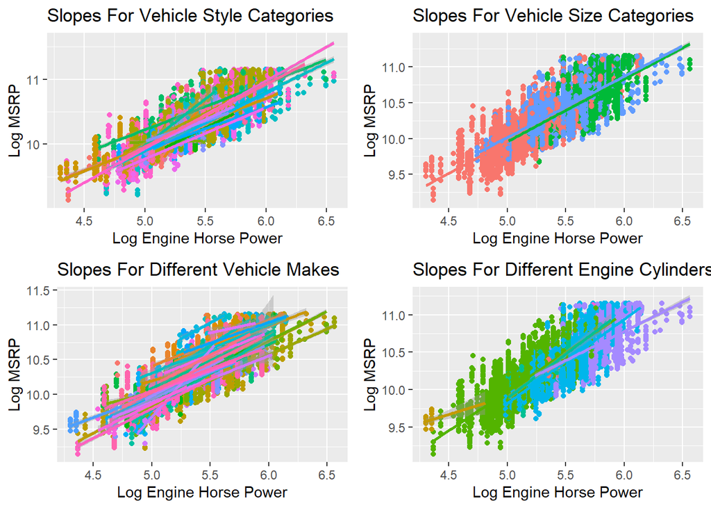

```r
hp_style<-backup_df %>% ggplot(aes(log_Engine.HP, log_MSRP, color = Vehicle.Style))+
  geom_point(show.legend = FALSE)+
  geom_smooth(method = 'lm', show.legend = F) +
  ggtitle("Slopes For Vehicle Style Categories")+
  xlab('Log Engine Horse Power')+
  ylab('Log MSRP')

hp_size<- backup_df %>% ggplot(aes(log_Engine.HP, log_MSRP, color = Vehicle.Size))+
  geom_point(show.legend = F)+
  geom_smooth(method = 'lm', show.legend = F)+
  ggtitle("Slopes For Vehicle Size Categories")+
  xlab('Log Engine Horse Power')+
  ylab('Log MSRP')

hp_make<- backup_df %>% ggplot(aes(log_Engine.HP, log_MSRP, color = Make))+
  geom_point(show.legend = FALSE)+
  geom_smooth(method = 'lm', show.legend = F)+
  ggtitle("Slopes For Different Vehicle Makes")+
  xlab('Log Engine Horse Power')+
  ylab('Log MSRP')

hp_cylinder <- backup_df %>% ggplot(aes(log_Engine.HP, log_MSRP, color = Engine.Cylinders))+
  geom_point(show.legend = FALSE)+
  geom_smooth(method = 'lm', show.legend = F)+
  ggtitle("Slopes For Different Engine Cylinders")+
  xlab('Log Engine Horse Power')+
  ylab('Log MSRP')


gridExtra::grid.arrange(hp_style,
                        hp_size,
                        hp_make,
                        hp_cylinder,
                        ncol = 2)
```

### ANOVA Testing

In the following chunk of code, we run ANOVAs with interactions to assess the effect of a variable on another given it’s multiple levels. Doing this allows us to determine whether the relationship between the variables is independent or if the interaction modifies the relationship behavior.

```r
aov_1 <- aov(log_MSRP~log_Engine.HP* Vehicle.Size, backup_df)
summary(aov_1) # there is not suff. evidence of a need for interaction
```

```
##                              Df Sum Sq Mean Sq   F value Pr(>F)
## log_Engine.HP                 1  806.6   806.6 18669.724 <2e-16 ***
## Vehicle.Size                  2    5.1     2.5    58.913 <2e-16 ***
## log_Engine.HP:Vehicle.Size    2    0.1     0.1     1.281  0.278
## Residuals                  9148  395.2     0.0
## ---
## Signif. codes:  0 '***' 0.001 '**' 0.01 '*' 0.05 '.' 0.1 ' ' 1
```

```r
aov_2 <- aov(log_MSRP~log_Engine.HP*Make, backup_df)
summary(aov_2) # there is suff. evidence of a need for an interaction
```

```
##                      Df Sum Sq Mean Sq  F value Pr(>F)
## log_Engine.HP         1  806.6   806.6 34145.89 <2e-16 ***
## Make                 37  174.0     4.7   199.06 <2e-16 ***
## log_Engine.HP:Make   35   12.0     0.3    14.46 <2e-16 ***
## Residuals          9080  214.5     0.0
## ---
## Signif. codes:  0 '***' 0.001 '**' 0.01 '*' 0.05 '.' 0.1 ' ' 1
```

```r
aov_3 <- aov(log_MSRP~log_Engine.HP*Engine.Cylinders, backup_df)
summary(aov_3)# there is suff. evidence of a need for an interaction
```

```
##                                  Df Sum Sq Mean Sq  F value Pr(>F)
## log_Engine.HP                     1  806.6   806.6 19699.53 <2e-16 ***
## Engine.Cylinders                  6   21.9     3.6    88.94 <2e-16 ***
## log_Engine.HP:Engine.Cylinders    5    4.3     0.9    20.99 <2e-16 ***
## Residuals                      9141  374.3     0.0
## ---
## Signif. codes:  0 '***' 0.001 '**' 0.01 '*' 0.05 '.' 0.1 ' ' 1
```

```r
aov_4 <- aov(log_MSRP~log_Engine.HP*Vehicle.Style, backup_df)
summary(aov_4)# there is suff. evidence of a need for an interaction
```

```
##                               Df Sum Sq Mean Sq  F value Pr(>F)
## log_Engine.HP                  1  806.6   806.6 23083.27 <2e-16 ***
## Vehicle.Style                 15   65.3     4.4   124.66 <2e-16 ***
## log_Engine.HP:Vehicle.Style   15   16.3     1.1    31.17 <2e-16 ***
## Residuals                   9122  318.7     0.0
## ---
## Signif. codes:  0 '***' 0.001 '**' 0.01 '*' 0.05 '.' 0.1 ' ' 1
```

#### Complex Model

Using the results of the ANOVAs run above we can determine that various explanatory features have an effect on log_engine.hp. So that we can account for these effects we have created interaction terms in our complex model below.

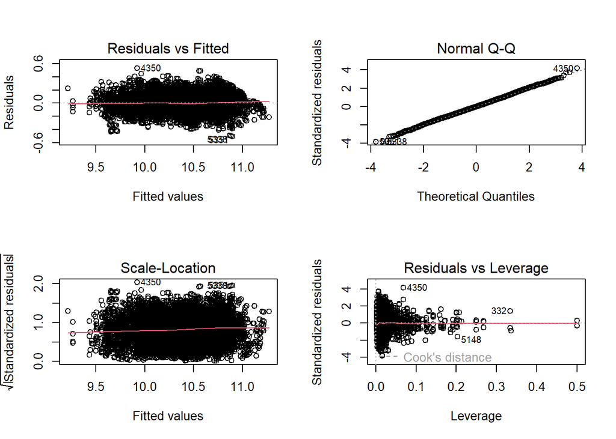

```r
complex_fit <- lm(log_MSRP~
                    Year+
                    log_Engine.HP*Engine.Cylinders+
                    log(Engine.HP)*Make+
                    log(Engine.HP)*Vehicle.Style,
                  training_b) # note not using training

# view coef. etc:
#summary(complex_fit)

# create 2x2 grid for plots
par(mfrow = c(2,2))
# diagnostics check
plot(complex_fit)
```

```r
#set seed for reprodu. outcome
set.seed(7)
# set crossvalidation parameters (non-repeating)
train_control<- trainControl(method = "cv", number = 10, repeats = 1)

# execute the k-fold cv based on RMSE as key metric
complex_kfold <- train(log_MSRP~ Year+
                    log_Engine.HP*Engine.Cylinders+
                    log(Engine.HP)*Make+
                    log(Engine.HP)*Vehicle.Style,
                  data=training_b,
                  method = "lm", trControl = train_control,
                  metric = "RMSE")
# view results
#print(complex_kfold)

complex_pred <- predict(complex_fit, interval = "predict", newdata = validate_b)

complex_RMSE<- sqrt(mean((complex_pred[,1] - validate_b$log_MSRP)^2))

ASE_func <- function(error){mean(error^2)}
ase <- ASE_func(complex_fit$residuals)
bic <- BIC(complex_fit)
rsqr <- summary(complex_fit)$r.squared
adj_rsqr<- summary(complex_fit)$adj.r.squared

cat("RMSE: ", complex_RMSE, "\nASE: ", ase, "\nR-Squared:", rsqr, "\nAdj.R-Squared:", adj_rsqr, "\nBIC: ",bic)
```

```
## RMSE:  0.133107
## ASE:  0.01706995
## R-Squared: 0.8713603
## Adj.R-Squared: 0.8693082
## BIC:  -7987.303
```

### Non-parametric | KNN Regression

```r
np_train <- car_train[,-c(1,3,5:7,9:11,15)]
np_test <- car_test[,-c(1,3,5:7,9:11,15)]
np_valid <- car_valid[,-c(1,3,5:7,9:11,15)]

#set seed for reprodu. outcome
set.seed(7)
# set crossvalidation parameters (non-repeating)
train_control<- trainControl(method = "cv", number = 10, repeats = 1)

# execute the k-fold cv based on RMSE as key metric
knn_cv <- train(log_MSRP~.,
                  data=np_train,
                  method = "knn", trControl = train_control,
                  metric = "RMSE")

knn_cv
```

```
## k-Nearest Neighbors
##
## 7323 samples
##    7 predictor
##
## No pre-processing
## Resampling: Cross-Validated (10 fold)
## Summary of sample sizes: 6591, 6591, 6591, 6590, 6590, 6591, ...
## Resampling results across tuning parameters:
##
##   k  RMSE       Rsquared   MAE
##   5  0.1165933  0.8982333  0.08996688
##   7  0.1191577  0.8936707  0.09242008
##   9  0.1223051  0.8879991  0.09518608
##
## RMSE was used to select the optimal model using the smallest value.
## The final value used for the model was k = 5.
```

```r
# np_train <- training_b[,-c(1,3,5:7,9:11,15)]
# np_test <- validate_b[,-c(1,3,5:7,9:11,15)]

# training data split into input and output
train_x = np_train[,!colnames(np_train)== "log_MSRP"]
train_y = as.numeric(unlist(np_train[,colnames(np_train)=="log_MSRP"]))

# test set split into input and output
test_x = np_test[,!colnames(np_test) == "log_MSRP"]
test_y = as.numeric(unlist(np_test[,colnames(np_test)=="log_MSRP"]))

#knn regression
knn_reg = knnreg(train_x, train_y)

pred_y_knn = predict(knn_reg, test_x)

mse = mean((test_y - pred_y_knn)^2)
mae = MAE(test_y, pred_y_knn)
rmse = RMSE(test_y, pred_y_knn)

cat("MSE: ", mse, "\nMAE: ", mae, "\nRMSE: ", rmse)
```

```
## MSE:  0.01003827
## MAE:  0.07718006
## RMSE:  0.1001912
```

### Non-Parametric | KNN Regression Validation

```r
set.seed(7)
# training data split into input and output
train_x = np_train[,!colnames(np_train)== "log_MSRP"]
train_y = as.numeric(unlist(np_train[,colnames(np_train)=="log_MSRP"]))

# validation set split into input and output
test_x = np_valid[,!colnames(np_valid) == "log_MSRP"]
test_y = as.numeric(unlist(np_valid[,colnames(np_valid)=="log_MSRP"]))


knn_reg_valid = knnreg(train_x,train_y)
pred_y = predict(knn_reg_valid,test_x)



mse = mean((test_y - pred_y)^2)
mae = MAE(test_y, pred_y)
rmse = RMSE(test_y, pred_y)
cat("MSE: ", mse, "\nMAE: ", mae, "\nRMSE: ", rmse)
```

```
## MSE:  0.009408815
## MAE:  0.075823
## RMSE:  0.09699905
```

### Non-Parametric | Regression Tree

```r
np_train<- np_train[,-2]
np_valid <- np_valid[,-2]
par(mfrow= c(2,2))
# tree
tree= rpart::rpart(log_MSRP~.,data = np_train, method = "anova")
rpart::printcp(tree)
```

```
##
## Regression tree:
## rpart::rpart(formula = log_MSRP ~ ., data = np_train, method = "anova")
##
## Variables actually used in tree construction:
## [1] city.mpg      log_Engine.HP
##
## Root node error: 974.5/7323 = 0.13307
##
## n= 7323
##
##         CP nsplit rel error  xerror      xstd
## 1 0.512766      0   1.00000 1.00024 0.0148563
## 2 0.084334      1   0.48723 0.48837 0.0076537
## 3 0.059770      2   0.40290 0.40537 0.0063512
## 4 0.013536      3   0.34313 0.34707 0.0057065
## 5 0.010839      4   0.32959 0.33590 0.0055968
## 6 0.010605      5   0.31876 0.32737 0.0054798
## 7 0.010000      6   0.30815 0.31733 0.0053765
```

```r
rpart::plotcp(tree)
summary(tree)
```

```
## Call:
## rpart::rpart(formula = log_MSRP ~ ., data = np_train, method = "anova")
##   n= 7323
##
##           CP nsplit rel error    xerror        xstd
## 1 0.51276640      0 1.0000000 1.0002372 0.014856296
## 2 0.08433410      1 0.4872336 0.4883658 0.007653719
## 3 0.05976953      2 0.4028995 0.4053727 0.006351182
## 4 0.01353598      3 0.3431300 0.3470669 0.005706525
## 5 0.01083894      4 0.3295940 0.3359010 0.005596820
## 6 0.01060453      5 0.3187551 0.3273731 0.005479793
## 7 0.01000000      6 0.3081505 0.3173292 0.005376491
##
## Variable importance
##   log_Engine.HP        city.mpg     highway.MPG            Year      Popularity
##              51              23              18               6               2
## Number.of.Doors
##               1
##
## Node number 1: 7323 observations,    complexity param=0.5127664
##   mean=10.34272, MSE=0.1330734
##   left son=2 (3389 obs) right son=3 (3934 obs)
##   Primary splits:
##       log_Engine.HP < 5.375268 to the left,  improve=0.51276640, (0 missing)
##       city.mpg      < 21.5     to the right, improve=0.17093310, (0 missing)
##       highway.MPG   < 31.5     to the right, improve=0.13369320, (0 missing)
##       Year          < 2009.5   to the left,  improve=0.09143806, (0 missing)
##       Popularity    < 207      to the right, improve=0.02931914, (0 missing)
##   Surrogate splits:
##       city.mpg        < 20.5     to the right, agree=0.774, adj=0.511, (0 split)
##       highway.MPG     < 29.5     to the right, agree=0.732, adj=0.421, (0 split)
##       Year            < 2006.5   to the left,  agree=0.604, adj=0.145, (0 split)
##       Popularity      < 943      to the left,  agree=0.558, adj=0.044, (0 split)
##       Number.of.Doors < 2.5      to the left,  agree=0.540, adj=0.006, (0 split)
##
## Node number 2: 3389 observations,    complexity param=0.0843341
##   mean=10.06128, MSE=0.06526924
##   left son=4 (1337 obs) right son=5 (2052 obs)
##   Primary splits:
##       log_Engine.HP < 5.108967 to the left,  improve=0.37153810, (0 missing)
```

[output cut: 67 more lines]

```
##
## Node number 9: 927 observations
##   mean=9.934416, MSE=0.04137873
##
## Node number 12: 1613 observations
##   mean=10.43824, MSE=0.04014163
##
## Node number 13: 667 observations
##   mean=10.58623, MSE=0.04361974
##
## Node number 14: 1472 observations
##   mean=10.69993, MSE=0.0498075
##
## Node number 15: 182 observations
##   mean=10.9553, MSE=0.0401578
```

```r
plot(tree, uniform = TRUE,
     main = "classifcation tree for MSRP")
text(tree, use.n = TRUE, all = TRUE, cex=.8)

# tree Cross validation
k <- 10
set.seed(7)
cv_tree <- train(log_MSRP~., data = np_train, method = 'rpart',
                 trControl = trainControl(method = 'cv', number = k))

print(cv_tree)
```

```
## CART
##
## 7323 samples
##    6 predictor
##
## No pre-processing
## Resampling: Cross-Validated (10 fold)
## Summary of sample sizes: 6591, 6591, 6591, 6590, 6590, 6591, ...
## Resampling results across tuning parameters:
##
##   cp          RMSE       Rsquared   MAE
##   0.05976953  0.2249480  0.6201541  0.1800224
##   0.08433410  0.2419514  0.5591846  0.1941886
##   0.51276640  0.3215882  0.5023495  0.2599146
##
## RMSE was used to select the optimal model using the smallest value.
## The final value used for the model was cp = 0.05976953.
```

```r
# prediction
pred_y = predict(tree, test_x)
plot(pred_y, test_y)
abline(0,1)
#sqrt(mean((pred_y - test_y)^2)) RMSE
#print(data.frame(test_y,pred_y))


# regression analysis
mse = mean((test_y-pred_y)^2)
mae = MAE(test_y,pred_y)
rmse = RMSE(test_y,pred_y)


cat("MSE: ", mse, "\nMAE: ", mae, "\nRMSE: ", rmse)
```

```
## MSE:  0.03959885
## MAE:  0.1593347
## RMSE:  0.1989946
```

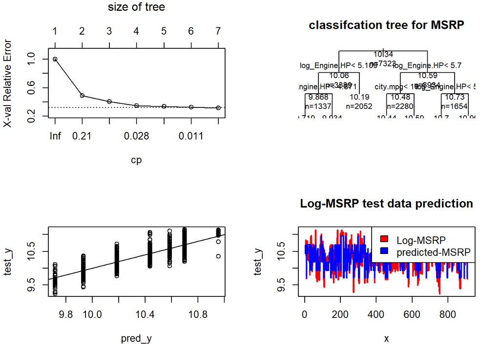

```r
# viz the pred
x = 1:length(test_y)
plot(x,test_y, col = "red", type = "l", lwd = 2,
     main = "Log-MSRP test data prediction")
lines(x, pred_y, col = "blue", lwd = 2)
legend("topright", legend = c("Log-MSRP", "predicted-MSRP"),
       fill = c("red", "blue"), col = 2:3, adj = c(0,0.6))
```

### Non-Parametric | Regression Tree Validation

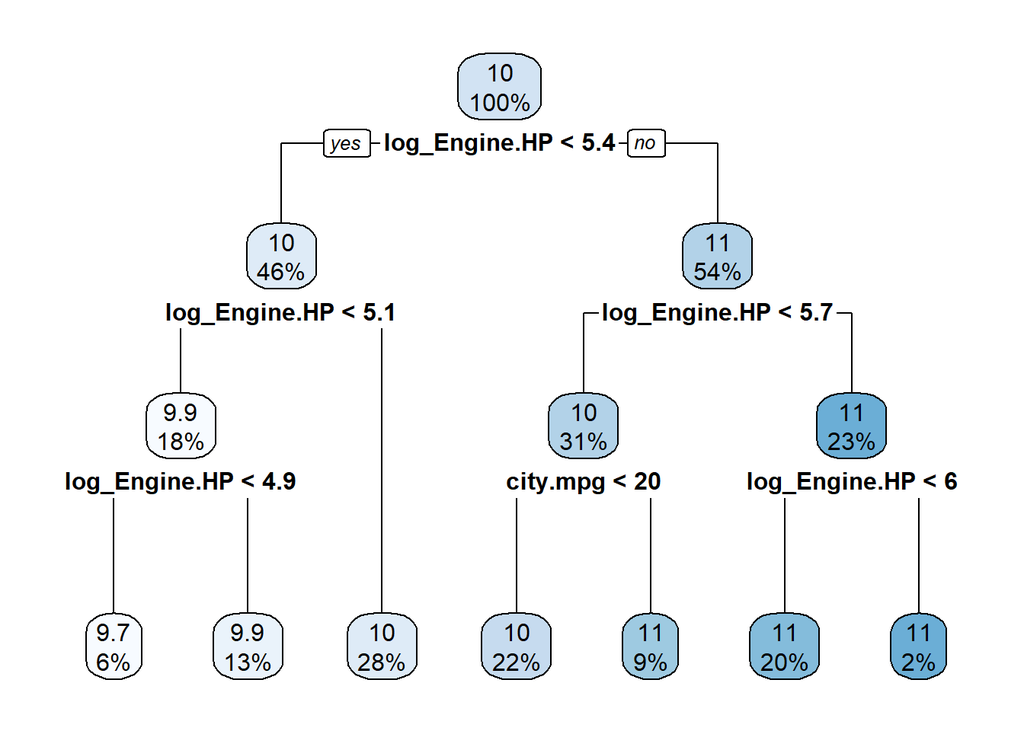

```r
library(rpart.plot)
set.seed(7)
# training data split into input and output
train_x = np_train[,!colnames(np_train)== "log_MSRP"]
train_y = as.numeric(unlist(np_train[,colnames(np_train)=="log_MSRP"]))

# validation set split into input and output
test_x = np_valid[,!colnames(np_valid) == "log_MSRP"]
test_y = as.numeric(unlist(np_valid[,colnames(np_valid)=="log_MSRP"]))

#par(mfrow= c(2,2))
# tree
tree= rpart::rpart(log_MSRP~.,data = np_train, method = "anova")
#rpart::printcp(tree) # errors and CP
#rpart::plotcp(tree) # complexity parameter table
prune_tree <- prune(tree, cp = .01)
# summary (prune_tree)
#summary(tree)
# plot(prune_tree, uniform = T)
# text(prune_tree,uniform=T, all = T, cex = .8)
# plot(tree, uniform = TRUE)
# text(tree, use.n = TRUE, all = TRUE, cex=.8)

rpart.plot(prune_tree) # pruned tree
```

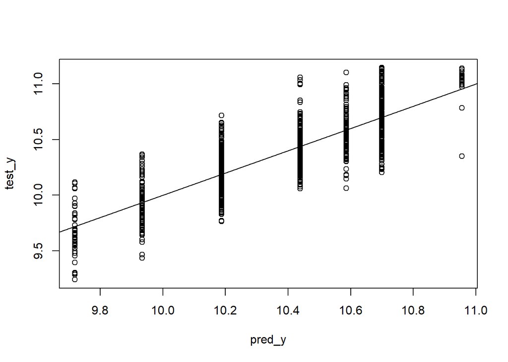

```r
# prediction
pred_y = predict(tree, test_x)
plot(pred_y, test_y)
abline(0,1)
```

```r
#sqrt(mean((pred_y - test_y)^2)) #RMSE
#print(data.frame(test_y,pred_y))


# regression analysis
mse = mean((test_y-pred_y)^2)
mae = MAE(test_y,pred_y)
rmse = RMSE(test_y,pred_y)

cat("MSE: ", mse, "\nMAE: ", mae, "\nRMSE: ", rmse)
```

```
## MSE:  0.03959885
## MAE:  0.1593347
## RMSE:  0.1989946
```

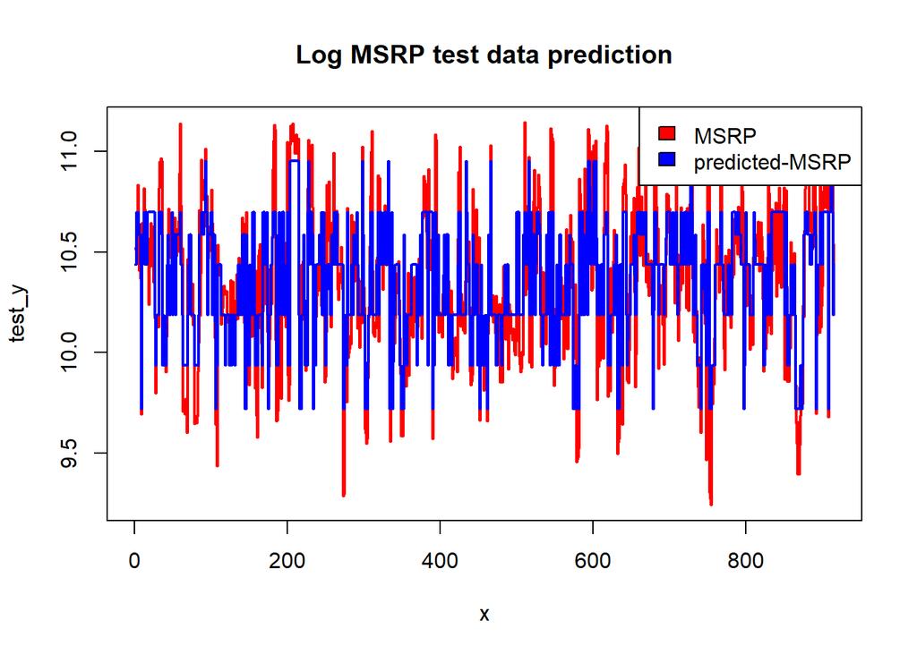

```r
x = 1:length(test_y)
plot(x,test_y, col = "red", type = "l", lwd = 2,
     main = "Log MSRP test data prediction")
lines(x, pred_y, col = "blue", lwd = 2)
legend("topright", legend = c("MSRP", "predicted-MSRP"),
       fill = c("red", "blue"), col = 2:3, adj = c(0,0.6))
```